# All problems

## All problems

unit_01-p07_continuous_distributions-01_estimate_area

unit_01-p07_continuous_distributions-02_normal_basic

unit_01-p07_continuous_distributions-03_standard_score

unit_01-p08_exam-q01_summary_statistics

unit_01-p08_exam-q02_proportions_from_list

unit_01-p08_exam-q03_read_histogram

unit_01-p08_exam-q04_compare_SD_same_shape

unit_01-p08_exam-q05_compare_SD_same_width

unit_01-p08_exam-q06_compare_boxplots

unit_01-p08_exam-q07_get_interval_of_typical_measurements

unit_01-p08_exam-q08_empirical_rule

unit_01-p08_exam-q09_standard_score

unit_01-p08_exam-q10_make_freq_dist_and_identify_histogram

## unit_01-p07_continuous_distributions-01_estimate_area

1. A continuous random variable (spinner/random number generator/infinite population) can be visualized with a density curve, a spinner, and a cumulative curve.

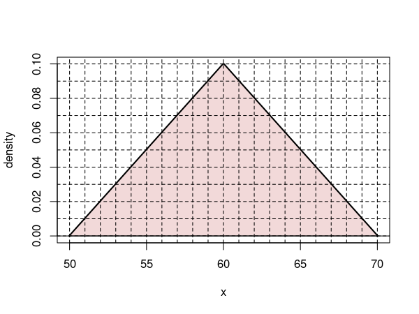

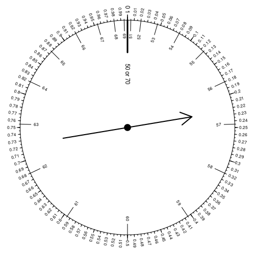

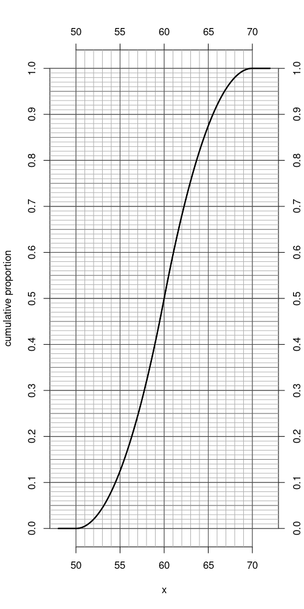

   1. Evaluate $\text{prop}[\mathbf{x}<68]$
   2. Evaluate $\text{prop}[\mathbf{x}>54]$
   3. Evaluate $\text{prop}[|\mathbf{x}-60|<2]$
   4. Determine integer $b$ such that $\text{prop}[\mathbf{x}<b]=0.82$
   5. Determine integer $b$ such that $\text{prop}[\mathbf{x}>b]=0.82$
   6. Determine integer $r$ such that $\text{prop}[|\mathbf{x}-63|<r]=0.42$

## unit_01-p07_continuous_distributions-02_normal_basic

### Background

2. In statistics, the word “normal” does not mean “typical”. Instead, “normal” refers to a very important continuous distribution: the [normal distribution](https://en.wikipedia.org/wiki/Normal_distribution). Normal distributions are important because random sums and random averages are approximately normal (see [central limit theorem](https://en.wikipedia.org/wiki/Central_limit_theorem)). For example, if you repeatedly roll 100 dice, taking the sum of each 100, those sums will be normally distributed (even though single rolls are [discrete-uniform](https://en.wikipedia.org/wiki/Discrete_uniform_distribution)ly distributed).

   A normal distribution has a bell-shaped density curve. The center and spread of the bell are dictated by two parameters: [mean](https://en.wikipedia.org/wiki/Mean) ($\mu$) and [standard deviation](https://en.wikipedia.org/wiki/Standard_deviation) ($\sigma$). The normal density curve is defined by the following equation:
   $$\text{normal density as function of x} = \frac{1}{\sigma\sqrt{2\pi}}e^{-\frac{1}{2}\left(\frac{x-\mu}{\sigma}\right)^2}$$
   where $\mu$ is the mean, $\sigma$ is the standard deviation, $\pi$ is the [ratio of a circle’s circumference to its diameter](https://en.wikipedia.org/wiki/Pi), and $e$ is Euler’s number.

   For the first exam, we are expected to know [the empirical rule](https://en.wikipedia.org/wiki/68%E2%80%9395%E2%80%9399.7_rule). We are going to round unconventionally, so for us it could be called the “68-96-100 rule”. It implies that in a normal distribution 68% of the measurements are within 1 standard deviation of the mean, 96% of the measurements are within 2 standard deviations of the mean, and 100% of the measurements are within 3 standard deviations of the mean.

   We can display our 68-96-100 rule with a spinner.

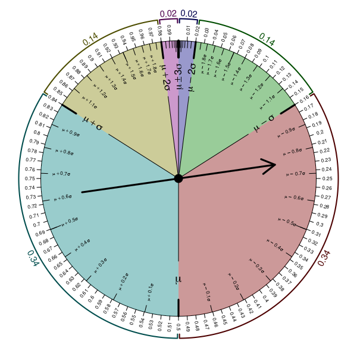

   And, we can display our 68-96-100 rule with a cumulative curve. In this case, we will introduce the notation of using $z$ as the multiplier of $\sigma$. For example, if $z=-2$, then the measurement is $\mu-2\sigma$. We call $z$ the [standard score](https://en.wikipedia.org/wiki/Standard_score).

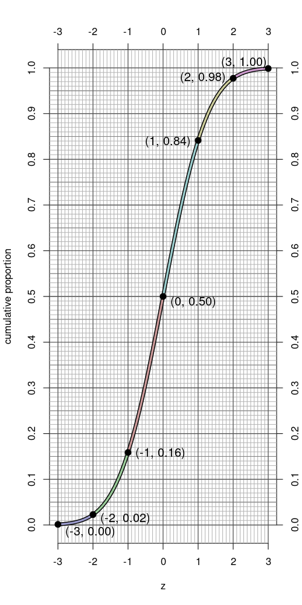

### Actual Question:

   Population $X$ (with infinite individuals) has measurements that are normally distributed with mean $\mu=36$ and standard deviation $\sigma=8$. Use the empirical rule (68-96-100 rule) to answer the following questions.
   1. Evaluate $\text{prop}[X<20]$.
   2. Evaluate $\text{prop}[X>28]$.
   3. Evaluate $\text{prop}[|X-36|<16]$.
   4. Determine boundary $b$ such that $\text{prop}[X<b]=0.5$.
   5. Determine boundary $b$ such that $\text{prop}[X>b]=0.16$.
   6. Determine radius $r$ such that $\text{prop}[|X-36|<r]=0.68$.

## unit_01-p07_continuous_distributions-03_standard_score

### Background

3. A [standard score](https://en.wikipedia.org/wiki/Standard_score) ($z$) can be calculated from a measurement ($x$), the population mean ($\mu$), and the population standard deviation ($\sigma$).
   $$z = \frac{x-\mu}{\sigma}$$
   With a little algebra, you can create another formula solved for the measurement.
   $$x = \mu+z\sigma$$

### Actual question

   A gambler is interested in the sum of 200 rolls of 10-sided dice. The process of summing 200 rolls of 10-sided dice can be repeated infinitely many times, giving independent results each time, so those sums can be thought of as an infinitely large population. This population happens to be approximately normal (see [central limit theorem](https://en.wikipedia.org/wiki/Central_limit_theorem)).

   The gambler knows how to calculate the population mean (see [discrete-uniform distribution](https://en.wikipedia.org/wiki/Discrete_uniform_distribution)).
   $$\mu = 200\cdot\frac{1+10}{2} = 1100$$
   She also knows how to calculate the population standard deviation.
   $$\sigma = \sqrt{200} \cdot \sqrt{\frac{10^2-1}{12}} = 40.62$$
   1. If the gambler rolled a sum of 1063 (in other words got a measurement $x=1063$), what is the standard score? (Determine $z$; you can round to the nearest hundredth.)
   2. If the gambler got a standard score of $z=2.31$, what is the sum? (Determine $x$, rounding to the nearest integer.)

## unit_01-p08_exam-q01_summary_statistics

4. A sample’s statistic typically approaches its corresponding population parameter, but with a small sample size there is regularly error. Let’s explore this idea with an example.

   A [geometric distribution](https://en.wikipedia.org/wiki/Geometric_distribution) is a well-studied discrete population. The spinner below represents a geometric distribution with the following population parameters.
   $$\mu = 4.58$$
   $$\sigma = 5.06$$

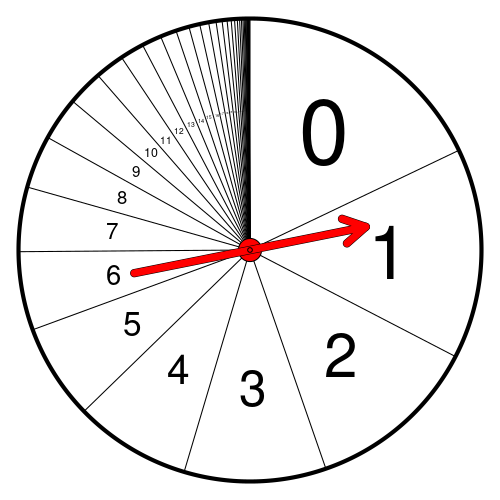

   That spinner was spun many times. The raw data is displayed below and can be downloaded as a CSV.

   ```
   4, 1, 5, 8, 3, 5, 9, 1, 5, 5, 2, 2, 1, 10, 14, 6, 4, 2, 2, 2, 5, 5, 0, 1, 1, 10, 1, 2, 5, 0, 19, 9, 0, 4, 0, 11, 4, 9, 0, 5, 0, 3, 0, 4, 3, 3, 1, 4, 9, 1, 0, 4, 0, 2, 18, 15, 1, 12, 10, 2, 3, 9, 1, 3, 3, 2, 14, 3, 4, 5, 0, 4, 5, 7
   ```

   Please calculate the following sample statistics.
   1. What is the sample size? (Determine $n$.)
   2. What is the sample mean? (Determine $\bar{x}$. You can round to nearest hundredth.)
   3. What is the **absolute difference** between the sample mean and population mean? (Calculate $|\bar{x}-\mu|$. You can round to nearest hundredth.)
   4. What is the sample median?
   5. What is the sample variance? (Determine $s^2$. Use Bessel’s correction. You can round to nearest hundredth.)
   6. What is the sample standard deviation? (Determine $s$. Use Bessel’s correction. You can round to nearest hundredth.)
   7. What is the **absolute difference** between the sample standard deviation and population standard deviation? (Calculate $|s-\sigma|$. You can round to nearest hundredth.)

## unit_01-p08_exam-q02_proportions_from_list

5. A [normal distribution](https://en.wikipedia.org/wiki/Geometric_distribution) is a well-studied continuous population. The spinner below represents a normal distribution with the following population parameters.
   $$\mu = 30$$
   $$\sigma = 6$$

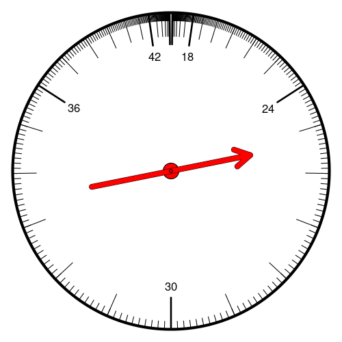

   That spinner was spun many times. The raw data is displayed below and can be downloaded as a CSV.

   ```
   33.2548, 33.3598, 19.5657, 26.4987, 40.2759, 28.0373, 36.1479, 23.3123, 34.8657, 37.8794, 34.9241, 38.0964, 21.8116, 40.1834, 33.9527, 22.7991, 33.7052, 24.2998, 26.1951, 25.1666, 28.116, 32.8059, 39.8734, 27.2734, 32.1075, 32.297, 21.2, 34.2302, 30.5916, 32.3643, 31.7892, 41.8649, 32.3959, 39.7304, 36.9958, 29.9469, 31.7999, 34.7532, 34.4129, 30.1612, 44.6825, 45.9181, 30.2394, 38.1054, 24.3658, 30.5778, 28.1016, 25.1397, 32.1316, 29.0761
   ```

   Please calculate the following sample proportions. (All answers can be rounded to nearest hundredth.)
   1. Calculate $\text{prop}[\mathbf{x}<26]$.
   2. Calculate $\text{prop}[\mathbf{x}>24.2]$.
   3. Calculate $\text{prop}[|\mathbf{x}-30|<10.4]$.
   4. Calculate $\text{prop}[|\mathbf{x}-30|>4.1]$.

## unit_01-p08_exam-q03_read_histogram

6. A standard eight-sided [die](https://en.wikipedia.org/wiki/Dice) was rolled many times, and the results were organized into the [histogram](https://en.wikipedia.org/wiki/Histogram) shown below.

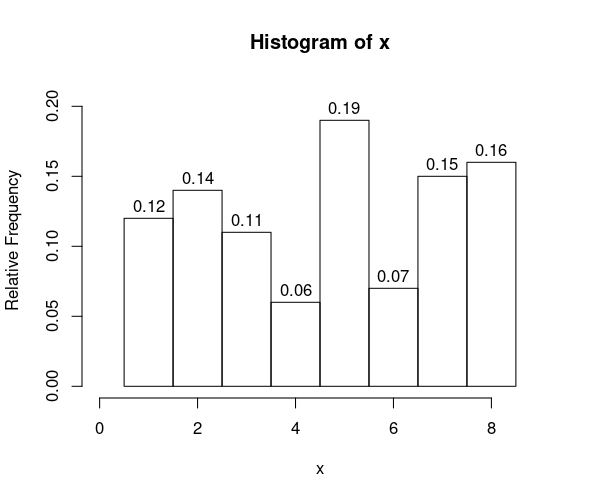

   1. Evaluate $\text{prop}[\mathbf{x}<4.5]$.
   2. Evaluate $\text{prop}[\mathbf{x}>5.5]$.
   3. Evaluate $\text{prop}[|\mathbf{x}-3|<1.5]$.
   4. Evaluate $\text{prop}[|\mathbf{x}-5|>2.5]$.
   5. Evaluate half-integer boundary $b$ such that $\text{prop}[\mathbf{x}<b] = 0.84$.
   6. Evaluate half-integer boundary $b$ such that $\text{prop}[\mathbf{x}>b] = 0.74$.
   7. Evaluate integer radius $r$ such that $\text{prop}[|\mathbf{x}-5.5|<r] = 0.47$.
   8. Evaluate half-integer radius $r$ such that $\text{prop}[|\mathbf{x}-3|>r] = 0.69$.

## unit_01-p08_exam-q04_compare_SD_same_shape

7. Three large samples were taken from three different populations. Their distributions are shown as histograms.

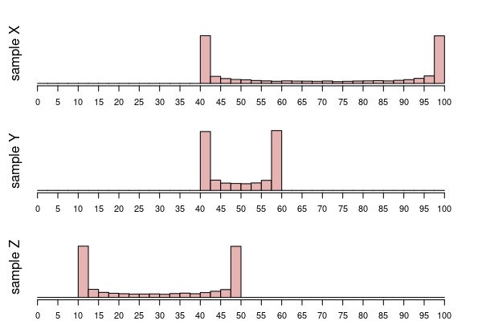

   1. Which sample has the smallest mean? X / Y / Z
   2. Which sample has the largest mean? X / Y / Z
   3. Which sample has the smallest standard deviation? X / Y / Z
   4. Which sample has the largest standard deviation? X / Y / Z

## unit_01-p08_exam-q05_compare_SD_same_width

8. Three large samples were taken from three different populations. Their distributions are shown as histograms.

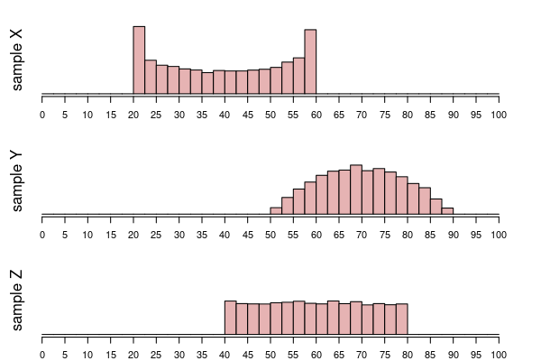

   1. Which sample has the smallest mean? X / Y / Z
   2. Which sample has the largest mean? X / Y / Z
   3. Which sample has the smallest standard deviation? X / Y / Z
   4. Which sample has the largest standard deviation? X / Y / Z

## unit_01-p08_exam-q06_compare_boxplots

9. Five different populations were sampled, and the measurements were visualized as five [boxplots](https://en.wikipedia.org/wiki/Box_plot). (Note: typical boxplots indicate outliers with dots. For simplicity, these boxplots include all outliers in the whiskers.)

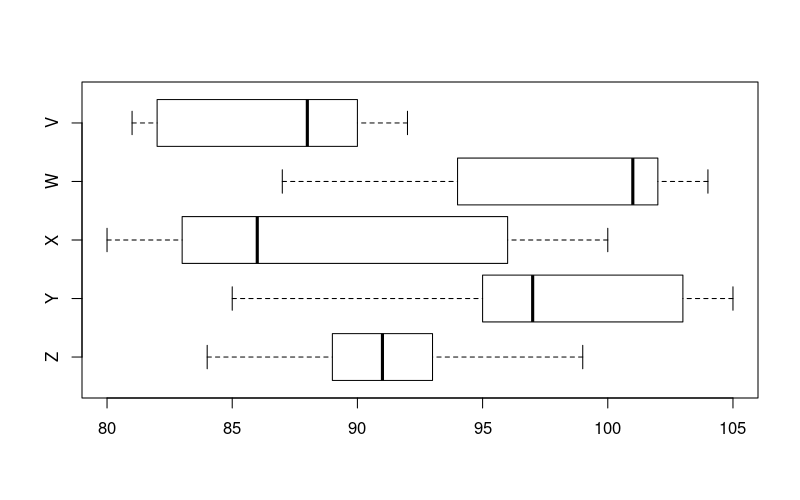

   1. Which sample contains the largest value? V / W / X / Y / Z
   2. Which sample contains the smallest value? V / W / X / Y / Z
   3. Which sample has the largest median? V / W / X / Y / Z
   4. Which sample has the smallest median? V / W / X / Y / Z
   5. Which sample has the largest IQR? V / W / X / Y / Z
   6. Which sample has the smallest IQR? V / W / X / Y / Z

## unit_01-p08_exam-q07_get_interval_of_typical_measurements

10. When measuring individuals from a population, we expect most measurements to be within the *interval of typical measurements*. We will define the interval of typical measurements (using interval notation):
    $$\text{interval of typical measurements} = (\mu-2\sigma,\,\mu+2\sigma)$$
    In other words, we expect we expect most measurements to be between two bounds.
    $$\text{lower bound of interval of typical measurements} = \mu-2\sigma$$
    $$\text{upper bound of interval of typical measurements} = \mu+2\sigma$$

### Actual Question

    A population of lizards has a mean length of $\mu = 65.6$ cm and a standard deviation of $\sigma=3.5$ cm. Determine the interval of typical measurements.
    1. Determine the lower bound of the interval of typical measurements.
    2. Determine the upper bound of the interval of typical measurements.

## unit_01-p08_exam-q08_empirical_rule

    Population $X$ has measurements that are normally distributed with mean $\mu=34$ and standard deviation $\sigma=3$. Use the empirical rule (68-96-100 rule) to answer the following questions.
    1. Evaluate $\text{prop}[X<31]$.
    2. Evaluate $\text{prop}[X>37]$.
    3. Evaluate $\text{prop}[|X-34|<6]$.
    4. Determine boundary $b$ such that $\text{prop}[X<b]=0.02$.
    5. Determine boundary $b$ such that $\text{prop}[X>b]=0.02$.
    6. Determine radius $r$ such that $\text{prop}[|X-34|<r]=0.68$.

## unit_01-p08_exam-q09_standard_score

12. A [standard score](https://en.wikipedia.org/wiki/Standard_score) ($z$) can be calculated from a measurement ($x$), the population mean ($\mu$), and the population standard deviation ($\sigma$).
    $$z = \frac{x-\mu}{\sigma}$$

    The following (normal) spinner has population mean $\mu=70$ and population standard deviation $\sigma=5$.

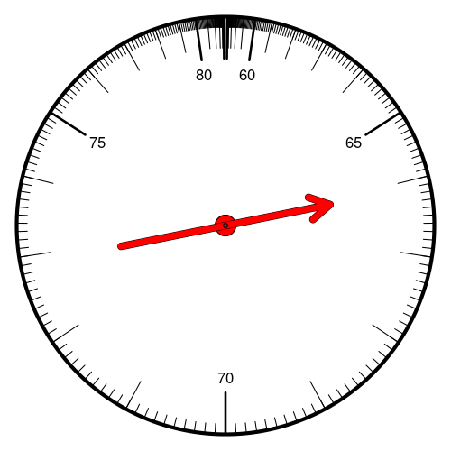

    1. If a spin has a measurement $x=73.25$, what is the standard score ($z$)?
    2. If a spin has a standard score $z=1.8$, what is the measurement ($x$)?

## unit_01-p08_exam-q10_make_freq_dist_and_identify_histogram

13. A sample of size $n=400$ was taken from an unknown population.

    ```
     2.75, 3.11, 7.39, 0.80, 4.56, 8.99, 3.72, 1.95, 0.47, 2.61,
     8.33, 3.55, 5.37, 0.54, 0.51, 1.69, 1.33, 9.92, 7.41, 8.30,
     8.26, 9.00, 3.61, 3.99, 2.44, 0.87, 8.01, 9.23, 9.86, 1.84,
     8.02, 4.35, 9.49, 2.44, 5.50, 2.13, 3.36, 9.74, 4.00, 9.22,
     5.58, 4.44, 5.41, 1.64, 2.72, 9.25, 0.70, 5.94, 1.16, 9.22,
     7.70, 0.11, 4.40, 2.09, 8.79, 1.44, 5.94, 3.32, 9.06, 1.00,
     4.31, 3.87, 4.80, 0.40, 8.61, 9.70, 1.84, 3.96, 8.74, 2.93,
     1.18, 1.84, 3.61, 2.96, 0.38, 7.85, 2.34, 4.77, 5.07, 6.26,
     0.81, 5.40, 6.44, 4.04, 4.79, 5.07, 0.22, 7.05, 0.25, 4.66,
     6.28, 8.40, 6.18, 8.10, 5.97, 5.47, 4.87, 3.36, 7.14, 0.81,
     0.43, 4.59, 8.56, 5.18, 5.22, 3.69, 9.86, 6.87, 2.83, 7.73,
     3.86, 1.27, 2.81, 4.82, 9.08, 0.99, 7.50, 4.50, 6.19, 2.57,
     4.20, 9.39, 2.60, 0.69, 0.77, 0.38, 4.42, 1.07, 8.26, 5.88,
     2.52, 6.16, 6.78, 1.69, 9.93, 3.94, 7.60, 6.41, 7.29, 1.73,
     0.59, 6.21, 1.15, 9.94, 3.11, 5.40, 9.76, 7.42, 1.84, 1.15,
     3.59, 1.80, 2.18, 3.10, 9.18, 6.55, 9.76, 4.90, 6.47, 2.10,
     6.28, 4.94, 6.07, 3.15, 0.35, 9.51, 2.62, 7.85, 0.84, 6.78,
     3.24, 5.45, 4.75, 8.00, 9.84, 1.03, 3.22, 5.16, 0.94, 3.46,
     1.82, 0.71, 5.85, 5.06, 0.12, 8.19, 5.60, 7.67, 5.44, 4.91,
     8.48, 7.04, 5.16, 6.62, 6.00, 0.53, 0.74, 8.50, 9.99, 8.47,
     3.68, 2.84, 3.63, 4.31, 5.39, 0.62, 2.78, 4.80, 2.59, 5.77,
     6.76, 9.26, 6.24, 3.12, 1.00, 5.18, 9.93, 4.26, 2.58, 2.52,
     7.79, 1.74, 1.15, 2.49, 4.46, 7.30, 0.50, 7.00, 0.03, 3.60,
     6.03, 9.68, 0.31, 0.34, 0.60, 5.63, 2.76, 0.93, 0.91, 1.52,
     8.24, 7.86, 7.37, 4.85, 4.62, 4.72, 4.36, 7.27, 8.89, 4.90,
     0.40, 8.41, 6.40, 7.18, 5.60, 2.13, 7.25, 4.97, 5.91, 8.03,
     1.37, 1.08, 6.83, 4.08, 4.63, 3.98, 6.61, 1.37, 3.55, 6.42,
     8.74, 0.98, 3.28, 6.53, 9.66, 5.44, 4.31, 6.74, 0.98, 9.22,
     2.75, 3.61, 4.24, 4.70, 3.37, 9.54, 2.98, 8.60, 1.77, 0.44,
     5.53, 3.79, 6.29, 9.89, 7.98, 5.80, 1.70, 9.50, 1.26, 2.58,
     5.49, 3.88, 6.21, 0.30, 0.23, 5.22, 9.96, 1.78, 7.81, 2.87,
     2.04, 3.18, 9.65, 4.07, 1.50, 6.50, 2.78, 2.17, 0.15, 8.46,
     6.21, 6.41, 8.88, 8.11, 6.02, 0.52, 7.87, 8.20, 6.26, 1.36,
     8.89, 4.60, 1.18, 2.12, 4.11, 0.64, 4.31, 0.06, 3.18, 0.50,
     5.84, 6.72, 6.54, 0.23, 4.62, 5.64, 3.96, 7.30, 9.92, 4.20,
     7.93, 1.03, 6.38, 6.26, 1.08, 3.02, 7.10, 7.87, 0.49, 9.80,
     5.75, 8.31, 0.77, 0.24, 9.14, 0.91, 4.34, 1.63, 8.94, 8.18,
     1.64, 3.14, 2.99, 1.33, 2.37, 1.55, 0.35, 2.74, 8.35, 6.36,
     0.80, 4.64, 1.43, 8.63, 0.51, 1.11, 4.64, 5.55, 0.56, 0.80,
     8.97, 1.60, 6.51, 9.38, 8.83, 1.23, 7.46, 0.48, 5.67, 8.53
    ```

    You can download the data as a CSV. Determine which histogram visualizes the data, and describe the shape of the data.

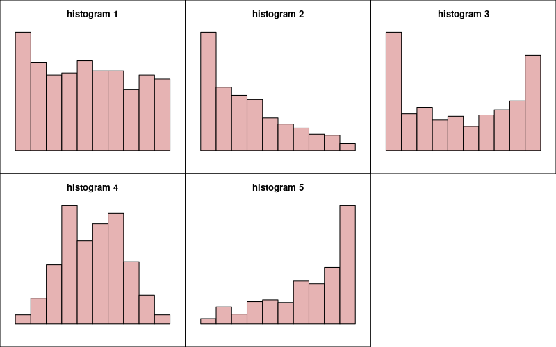

    - Which histogram is appropriate? distribution 1 / distribution 2 / distribution 3 / distribution 4 / distribution 5
    - Which shape description is appropriate? Bell / Uniform / Bimodal / Right-skew / Left-skew

unit_01-p07_continuous_distributions-01_estimate_area

unit_01-p07_continuous_distributions-02_normal_basic

unit_01-p07_continuous_distributions-03_standard_score

unit_01-p08_exam-q01_summary_statistics

unit_01-p08_exam-q02_proportions_from_list

unit_01-p08_exam-q03_read_histogram

unit_01-p08_exam-q04_compare_SD_same_shape

unit_01-p08_exam-q05_compare_SD_same_width

unit_01-p08_exam-q06_compare_boxplots

unit_01-p08_exam-q07_get_interval_of_typical_measurements

unit_01-p08_exam-q08_empirical_rule

unit_01-p08_exam-q09_standard_score

unit_01-p08_exam-q10_make_freq_dist_and_identify_histogram

   A continuous random variable (spinner/random number generator/infinite population) can be visualized with a density curve, a spinner, and a cumulative curve.

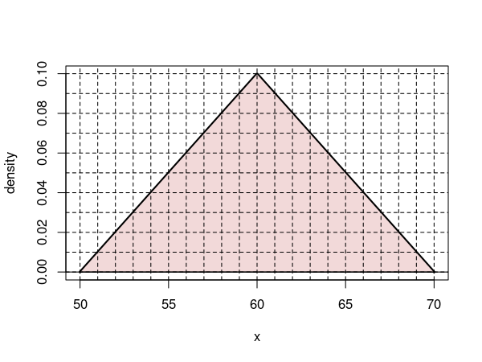

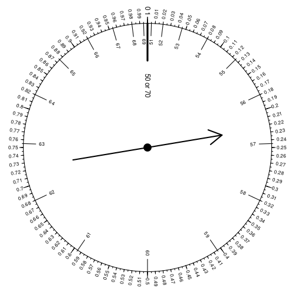

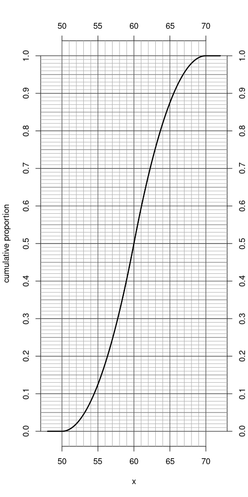

### Background

   In statistics, the word “normal” does not mean “typical”. Instead, “normal” refers to a very important continuous distribution: the [normal distribution](https://en.wikipedia.org/wiki/Normal_distribution). Normal distributions are important because random sums and random averages are approximately normal (see [central limit theorem](https://en.wikipedia.org/wiki/Central_limit_theorem)). For example, if you repeatedly roll 100 dice, taking the sum of each 100, those sums will be normally distributed (even though single rolls are [discrete-uniform](https://en.wikipedia.org/wiki/Discrete_uniform_distribution)ly distributed).

   A normal distribution has a bell-shaped density curve. The center and spread of the bell are dictated by two parameters: [mean](https://en.wikipedia.org/wiki/Mean) ($\mu$) and [standard deviation](https://en.wikipedia.org/wiki/Standard_deviation) ($\sigma$). The normal density curve is defined by the following equation:
   $$\text{normal density as function of x} = \frac{1}{\sigma\sqrt{2\pi}}e^{-\frac{1}{2}\left(\frac{x-\mu}{\sigma}\right)^2}$$
   where $\mu$ is the mean, $\sigma$ is the standard deviation, $\pi$ is the [ratio of a circle’s circumference to its diameter](https://en.wikipedia.org/wiki/Pi), and $e$ is Euler’s number.

   For the first exam, we are expected to know [the empirical rule](https://en.wikipedia.org/wiki/68%E2%80%9395%E2%80%9399.7_rule). We are going to round unconventionally, so for us it could be called the “68-96-100 rule”. It implies that in a normal distribution 68% of the measurements are within 1 standard deviation of the mean, 96% of the measurements are within 2 standard deviations of the mean, and 100% of the measurements are within 3 standard deviations of the mean.

   We can display our 68-96-100 rule with a spinner.

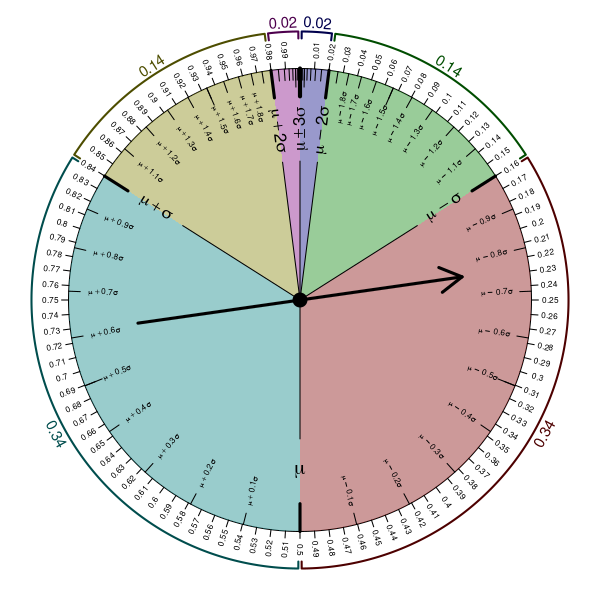

   And, we can display our 68-96-100 rule with a cumulative curve. In this case, we will introduce the notation of using $z$ as the multiplier of $\sigma$. For example, if $z=-2$, then the measurement is $\mu-2\sigma$. We call $z$ the [standard score](https://en.wikipedia.org/wiki/Standard_score).

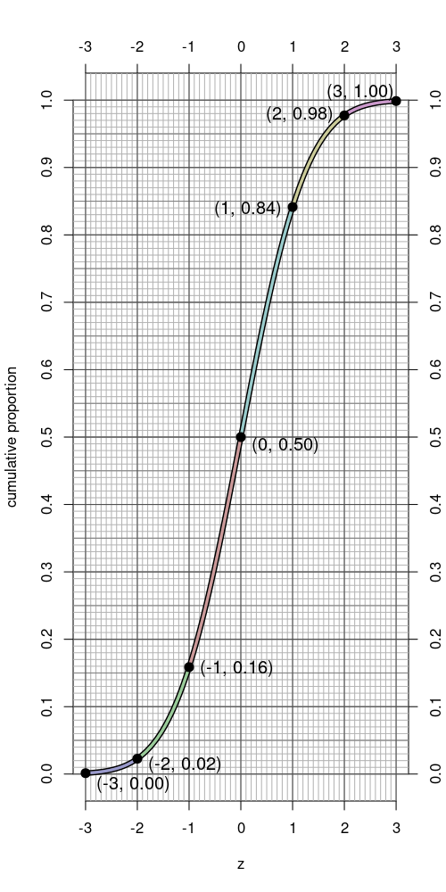

### Background

   A [standard score](https://en.wikipedia.org/wiki/Standard_score) ($z$) can be calculated from a measurement ($x$), the population mean ($\mu$), and the population standard deviation ($\sigma$).
   $$z = \frac{x-\mu}{\sigma}$$
   With a little algebra, you can create another formula solved for the measurement.
   $$x = \mu+z\sigma$$

### Actual question

   A sample’s statistic typically approaches its corresponding population parameter, but with a small sample size there is regularly error. Let’s explore this idea with an example.

   A [geometric distribution](https://en.wikipedia.org/wiki/Geometric_distribution) is a well-studied discrete population. The spinner below represents a geometric distribution with the following population parameters.
   $$\mu = 4.58$$
   $$\sigma = 5.06$$

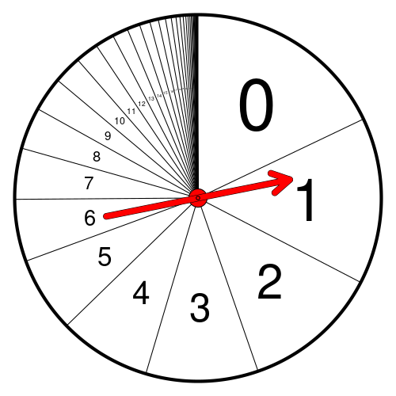

   That spinner was spun many times. The raw data is displayed below and can be downloaded as a CSV.

   ```
   4, 1, 5, 8, 3, 5, 9, 1, 5, 5, 2, 2, 1, 10, 14, 6, 4, 2, 2, 2, 5, 5, 0, 1, 1, 10, 1, 2, 5, 0, 19, 9, 0, 4, 0, 11, 4, 9, 0, 5, 0, 3, 0, 4, 3, 3, 1, 4, 9, 1, 0, 4, 0, 2, 18, 15, 1, 12, 10, 2, 3, 9, 1, 3, 3, 2, 14, 3, 4, 5, 0, 4, 5, 7
   ```

   A [normal distribution](https://en.wikipedia.org/wiki/Geometric_distribution) is a well-studied continuous population. The spinner below represents a normal distribution with the following population parameters.
   $$\mu = 30$$
   $$\sigma = 6$$

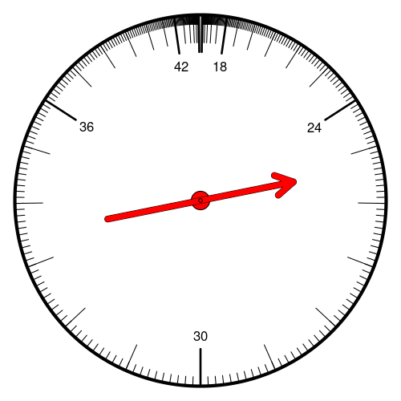

   That spinner was spun many times. The raw data is displayed below and can be downloaded as a CSV.

   ```
   33.2548, 33.3598, 19.5657, 26.4987, 40.2759, 28.0373, 36.1479, 23.3123, 34.8657, 37.8794, 34.9241, 38.0964, 21.8116, 40.1834, 33.9527, 22.7991, 33.7052, 24.2998, 26.1951, 25.1666, 28.116, 32.8059, 39.8734, 27.2734, 32.1075, 32.297, 21.2, 34.2302, 30.5916, 32.3643, 31.7892, 41.8649, 32.3959, 39.7304, 36.9958, 29.9469, 31.7999, 34.7532, 34.4129, 30.1612, 44.6825, 45.9181, 30.2394, 38.1054, 24.3658, 30.5778, 28.1016, 25.1397, 32.1316, 29.0761
   ```

   A standard eight-sided [die](https://en.wikipedia.org/wiki/Dice) was rolled many times, and the results were organized into the [histogram](https://en.wikipedia.org/wiki/Histogram) shown below.

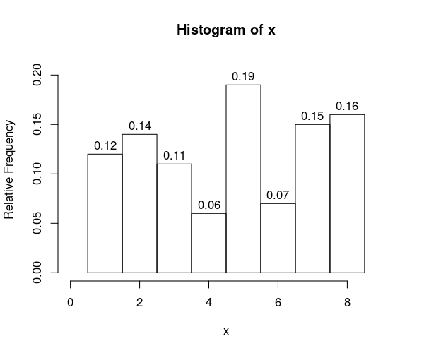

   Three large samples were taken from three different populations. Their distributions are shown as histograms.

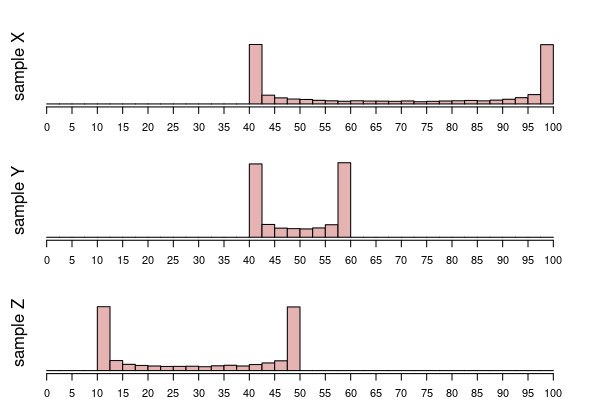

   Three large samples were taken from three different populations. Their distributions are shown as histograms.

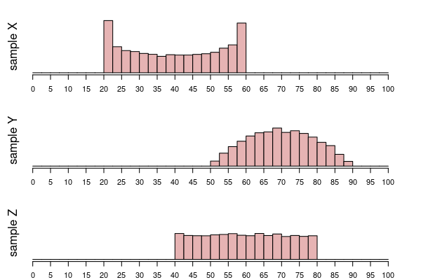

   Five different populations were sampled, and the measurements were visualized as five [boxplots](https://en.wikipedia.org/wiki/Box_plot). (Note: typical boxplots indicate outliers with dots. For simplicity, these boxplots include all outliers in the whiskers.)

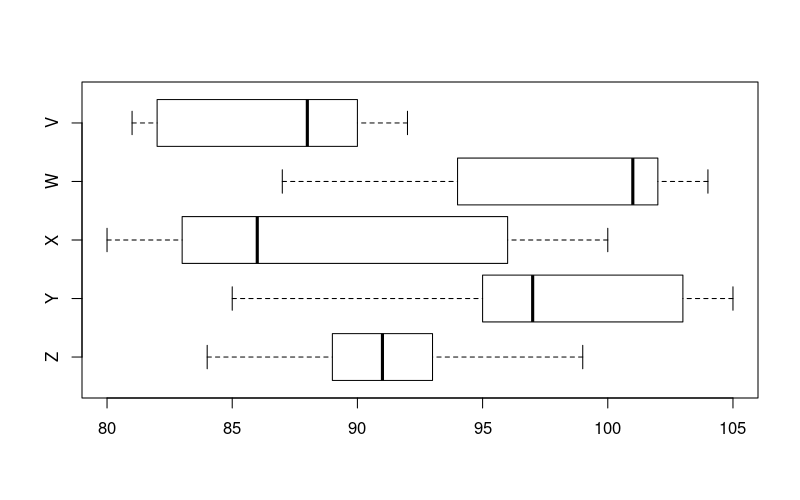

    When measuring individuals from a population, we expect most measurements to be within the *interval of typical measurements*. We will define the interval of typical measurements (using interval notation):
    $$\text{interval of typical measurements} = (\mu-2\sigma,\,\mu+2\sigma)$$
    In other words, we expect we expect most measurements to be between two bounds.
    $$\text{lower bound of interval of typical measurements} = \mu-2\sigma$$
    $$\text{upper bound of interval of typical measurements} = \mu+2\sigma$$

    A [standard score](https://en.wikipedia.org/wiki/Standard_score) ($z$) can be calculated from a measurement ($x$), the population mean ($\mu$), and the population standard deviation ($\sigma$).
    $$z = \frac{x-\mu}{\sigma}$$

    The following (normal) spinner has population mean $\mu=70$ and population standard deviation $\sigma=5$.

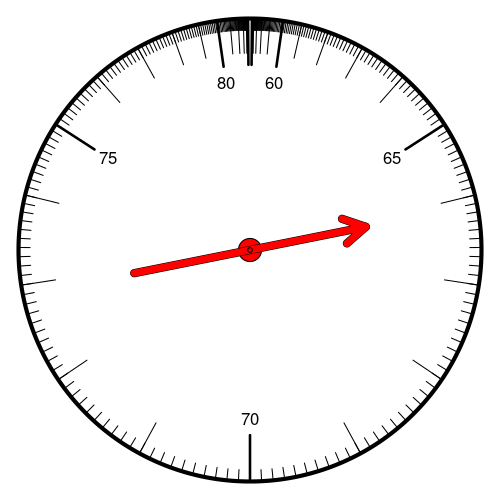

    A sample of size $n=400$ was taken from an unknown population.

    ```
     2.75, 3.11, 7.39, 0.80, 4.56, 8.99, 3.72, 1.95, 0.47, 2.61,
     8.33, 3.55, 5.37, 0.54, 0.51, 1.69, 1.33, 9.92, 7.41, 8.30,
     8.26, 9.00, 3.61, 3.99, 2.44, 0.87, 8.01, 9.23, 9.86, 1.84,
     8.02, 4.35, 9.49, 2.44, 5.50, 2.13, 3.36, 9.74, 4.00, 9.22,
     5.58, 4.44, 5.41, 1.64, 2.72, 9.25, 0.70, 5.94, 1.16, 9.22,
     7.70, 0.11, 4.40, 2.09, 8.79, 1.44, 5.94, 3.32, 9.06, 1.00,
     4.31, 3.87, 4.80, 0.40, 8.61, 9.70, 1.84, 3.96, 8.74, 2.93,
     1.18, 1.84, 3.61, 2.96, 0.38, 7.85, 2.34, 4.77, 5.07, 6.26,
     0.81, 5.40, 6.44, 4.04, 4.79, 5.07, 0.22, 7.05, 0.25, 4.66,
     6.28, 8.40, 6.18, 8.10, 5.97, 5.47, 4.87, 3.36, 7.14, 0.81,
     0.43, 4.59, 8.56, 5.18, 5.22, 3.69, 9.86, 6.87, 2.83, 7.73,
     3.86, 1.27, 2.81, 4.82, 9.08, 0.99, 7.50, 4.50, 6.19, 2.57,
     4.20, 9.39, 2.60, 0.69, 0.77, 0.38, 4.42, 1.07, 8.26, 5.88,
     2.52, 6.16, 6.78, 1.69, 9.93, 3.94, 7.60, 6.41, 7.29, 1.73,
     0.59, 6.21, 1.15, 9.94, 3.11, 5.40, 9.76, 7.42, 1.84, 1.15,
     3.59, 1.80, 2.18, 3.10, 9.18, 6.55, 9.76, 4.90, 6.47, 2.10,
     6.28, 4.94, 6.07, 3.15, 0.35, 9.51, 2.62, 7.85, 0.84, 6.78,
     3.24, 5.45, 4.75, 8.00, 9.84, 1.03, 3.22, 5.16, 0.94, 3.46,
     1.82, 0.71, 5.85, 5.06, 0.12, 8.19, 5.60, 7.67, 5.44, 4.91,
     8.48, 7.04, 5.16, 6.62, 6.00, 0.53, 0.74, 8.50, 9.99, 8.47,
     3.68, 2.84, 3.63, 4.31, 5.39, 0.62, 2.78, 4.80, 2.59, 5.77,
     6.76, 9.26, 6.24, 3.12, 1.00, 5.18, 9.93, 4.26, 2.58, 2.52,
     7.79, 1.74, 1.15, 2.49, 4.46, 7.30, 0.50, 7.00, 0.03, 3.60,
     6.03, 9.68, 0.31, 0.34, 0.60, 5.63, 2.76, 0.93, 0.91, 1.52,
     8.24, 7.86, 7.37, 4.85, 4.62, 4.72, 4.36, 7.27, 8.89, 4.90,
     0.40, 8.41, 6.40, 7.18, 5.60, 2.13, 7.25, 4.97, 5.91, 8.03,
     1.37, 1.08, 6.83, 4.08, 4.63, 3.98, 6.61, 1.37, 3.55, 6.42,
     8.74, 0.98, 3.28, 6.53, 9.66, 5.44, 4.31, 6.74, 0.98, 9.22,
     2.75, 3.61, 4.24, 4.70, 3.37, 9.54, 2.98, 8.60, 1.77, 0.44,
     5.53, 3.79, 6.29, 9.89, 7.98, 5.80, 1.70, 9.50, 1.26, 2.58,
     5.49, 3.88, 6.21, 0.30, 0.23, 5.22, 9.96, 1.78, 7.81, 2.87,
     2.04, 3.18, 9.65, 4.07, 1.50, 6.50, 2.78, 2.17, 0.15, 8.46,
     6.21, 6.41, 8.88, 8.11, 6.02, 0.52, 7.87, 8.20, 6.26, 1.36,
     8.89, 4.60, 1.18, 2.12, 4.11, 0.64, 4.31, 0.06, 3.18, 0.50,
     5.84, 6.72, 6.54, 0.23, 4.62, 5.64, 3.96, 7.30, 9.92, 4.20,
     7.93, 1.03, 6.38, 6.26, 1.08, 3.02, 7.10, 7.87, 0.49, 9.80,
     5.75, 8.31, 0.77, 0.24, 9.14, 0.91, 4.34, 1.63, 8.94, 8.18,
     1.64, 3.14, 2.99, 1.33, 2.37, 1.55, 0.35, 2.74, 8.35, 6.36,
     0.80, 4.64, 1.43, 8.63, 0.51, 1.11, 4.64, 5.55, 0.56, 0.80,
     8.97, 1.60, 6.51, 9.38, 8.83, 1.23, 7.46, 0.48, 5.67, 8.53
    ```

    You can download the data as a CSV. Determine which histogram visualizes the data, and describe the shape of the data.

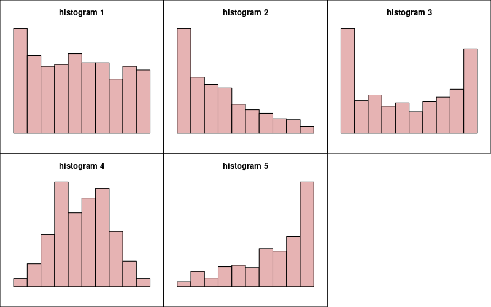

    - Which histogram is appropriate? distribution 1 / distribution 2 / distribution 3 / distribution 4 / distribution 5
    - Which shape description is appropriate? Bell / Uniform / Bimodal / Right-skew / Left-skew